# Introduction to the Command Line Interface

## What is the Command Line Interface?

Nearly ever computer comes with a CLI - Windows: Git Bash (See "Introduction to Git") - Mac/Linux: Terminal

## What can the CLI do?

The CLI can help you: - Navigate folders - Create files, folders, and programs - Edit files, folders, and programs - Run computer programs

## Basics of Directories

- "Directory" is just another name for folder
- Directories on your computer are organized like a tree
- Directories can be inside other directories
- We can navigate directories using the CLI

[figure not shown]

## Basics of Directories

- My "Debussy" directory is contained inside of my "Music" directory

[figure not shown]

## Basics of Directories

- One directory "up" from my Debussy directory is my Music directory

[figure not shown]

## Your computer's directory structure

- The directory structure on your computer looks something like this

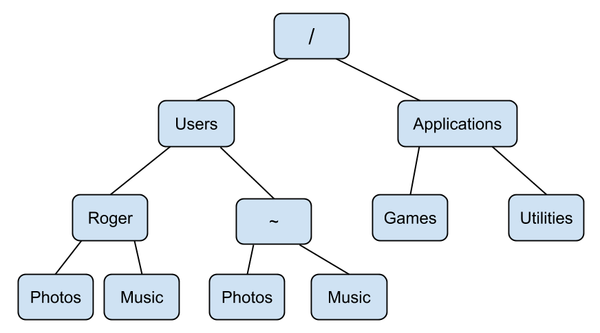

## Special directories: root

- The directory at the top of the tree is called the root directory
- The root directory contains all other directories
- The name of this directory is represented by a slash: `/`

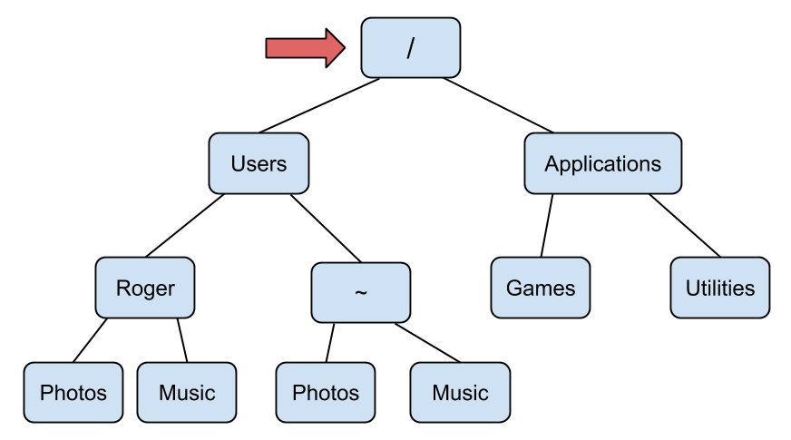

## Special directories: home

- Your home directory is represented by a tilde: `~`
- Your home directory usually contains most of your personal files, pictures, music, etc.
- The name of your home directory is usually the name you use to log into your computer

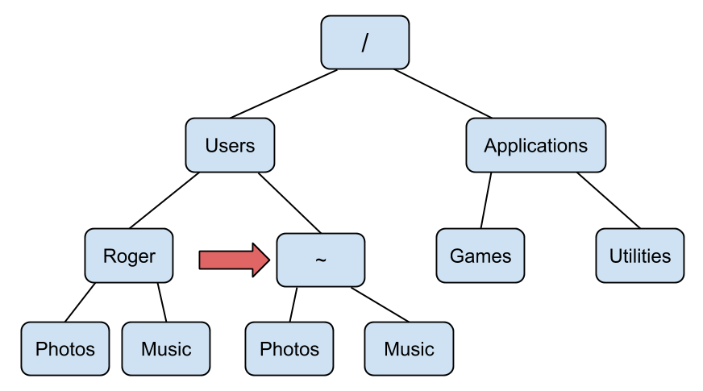

## Navigating directories with the CLI

Windows users: - Open the start menu - Search for Git Bash - Open Git Bash

[figure not shown]

## Navigating directories with the CLI

Mac users: - Open Spotlight - Search Terminal - Open Terminal

[figure not shown]

## CLI Basics

- When you open your CLI you will see your prompt, which will looks something like the name of your computer, followed by your username, followed by a `$`
- When you open your CLI you start in your home directory.
- Whatever directory you're currently working with in your CLI is called the "working directory"

[figure not shown]

## CLI Basics

- You can imagine tracing all of the directories from your root directory to the directory you're currently in.
- This is called the "path" to your working directory.

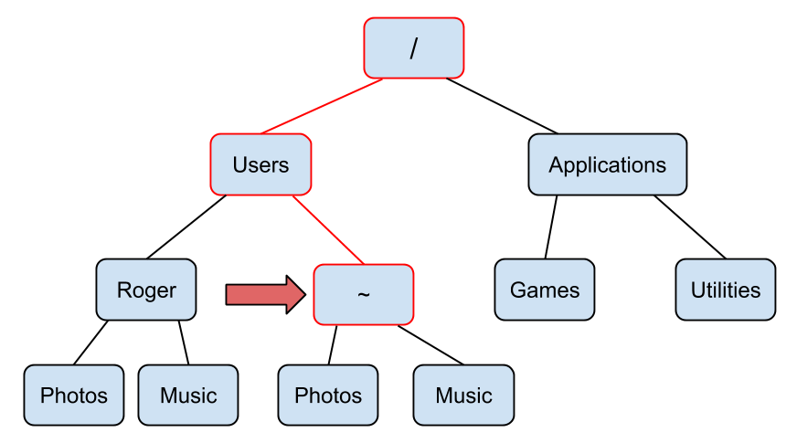

## CLI Basics

- In your CLI prompt, type `pwd` and press enter.
- This will display the path to your working directory.
- As you can see we get the prompt back after entering a command.

[figure not shown]

## CLI Commands

- You use the CLI prompt by typing in a command and pressing enter.
- `pwd` can be used at any time to display the path to your working directory (`pwd` is an abbreviation for "print working directory")

## CLI Commands

- CLI commands follow this recipe: *command flags arguments*
- *command* is the CLI command which does a specific task
- *flags* are options we give to the *command* to trigger certain behaviors, preceded by a `-`
- *arguments* can be what the *command* is going to modify, or other options for the *command*
- Depending on the *command*, there can be zero or more *flags* and *arguments*
- For example `pwd` is a *command* that requires no *flags* or *arguments*

## CLI Commands

- `pwd` displays the path to the current working directory

```bash
jeff$ pwd
/Users/jeff
jeff$
```

## CLI Commands

- `clear` will clear out the commands in your current CLI window

```bash
jeff$ pwd
/Users/jeff
jeff$ clear
```

```bash
jeff$
```

## CLI Commands

- `ls` lists files and folders in the current directory
- `ls -a` lists hidden and unhidden files and folders
- `ls -al` lists details for hidden and unhidden files and folders
- Notice that `-a` and `-l` are flags (they're preceded by a `-`)
- They can be combined into the flag: `-al`

```bash
jeff$ ls
Desktop   Photos   Music
jeff$ ls -a
Desktop   Photos   Music  .Trash  .DS_Store
jeff$
```

## CLI Commands

- `cd` stands for "change directory"
- `cd` takes as an argument the directory you want to visit
- `cd` with no argument takes you to your home directory
- `cd ..` allows you to change directory to one level above your current directory

```bash
jeff$ cd Music/Debussy
jeff$ pwd
/Users/jeff/Music/Debussy
jeff$ cd ..
jeff$ pwd
/Users/jeff/Music
jeff$ cd
jeff$ pwd
/Users/jeff
jeff$
```

## CLI Commands

- `mkdir` stands for "make directory"
- Just like: right click -> create new folder
- `mkdir` takes as an argument the name of the directory you're creating

```bash
jeff$ mkdir Documents
jeff$ ls
Desktop   Photos  Music   Documents
jeff$ cd Documents
jeff$ pwd
/Users/jeff/Documents
jeff$ cd
jeff$
```

## CLI Commands

- `touch` creates an empty file

```bash
jeff$ touch test_file
jeff$ ls
Desktop   Photos  Music   Documents   test_file
jeff$
```

## CLI Commands

- `cp` stands for "copy"
- `cp` takes as its first argument a file, and as its second argument the path to where you want the file to be copied

```bash
jeff$ cp test_file Documents
jeff$ cd Documents
jeff$ ls
test_file
jeff$ cd ..
jeff$
```

## CLI Commands

- `cp` can also be used for copying the contents of directories, but you must use the `-r` flag
- The line: `cp -r Documents More_docs` copies the contents of `Documents` into `More_docs`

```bash
jeff$ mkdir More_docs
jeff$ cp -r Documents More_docs
jeff$ cd More_docs
jeff$ ls
test_file
jeff$ cd ..
jeff$
```

## CLI Commands

- `rm` stands for "remove"
- `rm` takes the name of a file you wish to remove as its argument

```bash
jeff$ ls
Desktop   Photos  Music   Documents   More_docs   test_file
jeff$ rm test_file
jeff$ ls
Desktop   Photos  Music   Documents   More_docs
jeff$
```

## CLI Commands

- You can also use `rm` to delete entire directories and their contents by using the `-r` flag
- **Be very careful when you do this, there is no way to undo an `rm`**

```bash
jeff$ ls
Desktop   Photos  Music   Documents   More_docs
jeff$ rm -r More_docs
jeff$ ls
Desktop   Photos  Music   Documents
jeff$
```

## CLI Commands

- `mv` stands for "move"
- With `mv` you can move files between directories

```bash
jeff$ touch new_file
jeff$ mv new_file Documents
jeff$ ls
Desktop   Photos  Music   Documents
jeff$ cd Documents
jeff$ ls
test_file   new_file
jeff$
```

## CLI Commands

- You can also use `mv` to rename files

```bash
jeff$ ls
test_file   new_file
jeff$ mv new_file renamed_file
jeff$ ls
test_file renamed_file
jeff$
```

## CLI Commands

- `echo` will print whatever arguments you provide

```bash
jeff$ echo Hello World!
Hello World!
jeff$
```

## CLI Commands

- `date` will print today's date

```bash
jeff$ date
Mon Nov  4 20:48:03 EST 2013
jeff$
```

## Summary of Commands

- `pwd`
- `clear`
- `ls`
- `cd`
- `mkdir`
- `touch`
- `cp`
- `rm`
- `mv`
- `date`
- `echo`